# McCall Search Model

David Evans

2026-04-20

# Model Setup

## The Environment

### The McCall Search Model

- Worker lives for $T$ (possibly infinite) periods
- Can be either **unemployed** or **employed**
- Discounts the future at rate $\beta$
- If unemployed: receives a wage offer $\bar w_j$ with probability $p_j$
- Two choices each period:
  - **Accept**: receive wage $\bar w_j$ and become employed
  - **Reject**: receive unemployment benefits $c$ and remain unemployed

### Objective

- Worker maximizes expected discounted lifetime income:

$$\mathbb{E} \sum_{t=0}^T \beta^t y_t$$

where $y_t = c$ if unemployed and $y_t = w_t$ if employed

- Can be fired with probability $\alpha$ at the end of each period (begin by assuming $\alpha = 0$)

### The Decision Tree

[figure not shown]

- $2^n$ possible paths after $n$ periods — how to solve this efficiently?

### Employed vs. Unemployed

- An **unemployed worker** with wage offer $\bar w_j$ can reject the offer, receive $c$, and draw a new offer next period
- Or accept the offer, receive $\bar w_j$, and be employed next period at wage $\bar w_j$
- An **employed worker** with wage $\bar w_j$ can quit, receive $c$, and draw a new offer next period
- Or continue to work, receive $\bar w_j$, and be employed next period at wage $\bar w_j$

**Insight**

An employed worker deciding whether to keep wage $\bar w_j$ faces the same problem as an unemployed worker who just received offer $\bar w_j$.

### Setup Parameters

```julia
using Plots
using LinearAlgebra
```

```julia
β = 0.95       # discount factor
S = 50         # number of possible wage offers
w̄ = LinRange(1., 10., S)   # wage offers
p = ones(S)/S  # equal probability of each wage
c = 3.         # unemployment benefit
```

```
3.0
```

## Roadmap

### What We’ll Cover

1. **Finite Horizon** — solve the model by backward induction
2. **Solving with Functions** — package code into reusable functions
3. **Infinite Horizon** — take $T \to \infty$ with value function iteration
4. **Organizing with Structs** — group parameters using Julia `struct`s
5. **Firing Risk** — extend the model with job separation
6. **Comparative Statics** — how do policy changes affect outcomes?

# Finite Horizon

## One Period Problem

### Value with One Period Left

- What is the value of an unemployed worker who receives offer $\bar w_j$ in the **last** period?

$$V_{1,j} = \max\left\{ \bar w_j,\; c \right\}$$

- $V_{1,j}$ = value with **one period left** and wage offer $\bar w_j$

### Computing the One-Period Value

```julia
V1 = max.(w̄, c)   # V1[j] = max(w̄[j], c) for each j
```

```
50-element Vector{Float64}:
  3.0
  3.0
  3.0
  3.0
  3.0
  3.0
  3.0
  3.0
  3.0
  3.0
  ⋮
  8.53061224489796
  8.714285714285714
  8.89795918367347
  9.081632653061224
  9.26530612244898
  9.448979591836736
  9.63265306122449
  9.816326530612246
 10.0
```

### Plotting the One-Period Value

```julia
scatter(w̄, V1, label="V₁", legend=:topleft)
xlabel!("Wage")
ylabel!("Value (1 period left)")
```

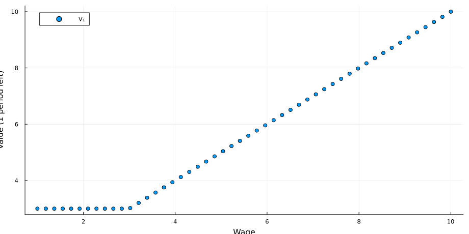

### Expected Value of a Random Offer

- Define $Q_1$ as the **expected value** of a random wage offer with 1 period left:

$$Q_1 = \sum_s p_s V_{1,s} = p \cdot V_1$$

```julia
Q1 = dot(p, V1)
```

```
5.737959183673469
```

## Two Period Problem

### Value with Two Periods Left

- Value of **accepting** offer $\bar w_s$:

$$\bar w_s + \beta V_{1,s}$$

- Value of **rejecting** the offer:

$$c + \beta Q_1$$

- The worker chooses the best option:

$$V_{2,s} = \max\left\{ \bar w_s + \beta V_{1,s},\; c + \beta Q_1 \right\}$$

### Computing Two-Period Values

```julia
V2accept = w̄ + β*V1       # value of accepting for each wage
V2reject = c + β*Q1        # value of rejecting (a scalar)
V2 = max.(V2accept, V2reject)
```

```
50-element Vector{Float64}:
  8.451061224489795
  8.451061224489795
  8.451061224489795
  8.451061224489795
  8.451061224489795
  8.451061224489795
  8.451061224489795
  8.451061224489795
  8.451061224489795
  8.451061224489795
  ⋮
 16.634693877551022
 16.99285714285714
 17.351020408163265
 17.709183673469386
 18.067346938775508
 18.425510204081633
 18.783673469387757
 19.14183673469388
 19.5
```

### Plotting the Two-Period Value

```julia
scatter(w̄, V2, label="V₂", legend=:topleft)
scatter!(w̄, V1, label="V₁")
xlabel!("Wage")
ylabel!("Value")
```

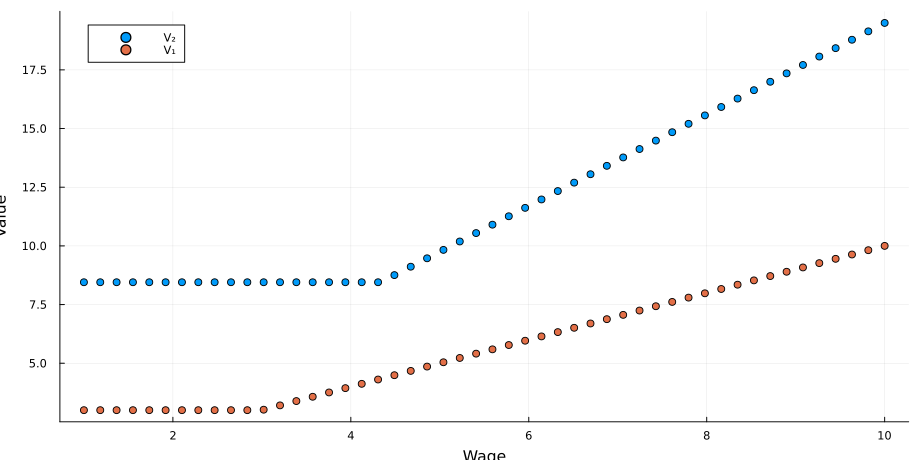

### Expected Value with Two Periods

```julia
Q2 = dot(p, V2)
```

```
11.970484897959183
```

- This can be used in the 3 period problem
- And then the 4-period problem
- And then the 5 period problem

## General $t$-Period Problem

### The Bellman Equation

- For a worker with $t$ periods left and wage offer $\bar w_s$:
- Value of **accepting**: $\bar w_s + \beta V_{t-1,s}$
- Value of **rejecting**: $c + \beta Q_{t-1}$

$$\boxed{V_{t,s} = \max\left\{ \bar w_s + \beta V_{t-1,s},\; c + \beta Q_{t-1} \right\}}$$

### Backward Induction

**Solution Strategy**

We solve **backwards** from the last period: compute $V_1$, then $V_2$, then $V_3$, and so on.

### Solving with a For Loop

```julia
T = 50                                # number of periods the worker lives
S = length(w̄)                        # number of possible wages
V = zeros(T, S)                       # V[t,s] = value with t periods left, offer s
Q = zeros(T)                          # Q[t] = expected value of random offer

V[1, :] = max.(c, w̄)                 # base case: last period, just pick max
Q[1] = dot(p, V[1, :])               # expected value in last period

for t in 2:T                          # build up from t=2 to t=T
    Vaccept = w̄ + β*V[t-1, :]        # wage today + discounted continuation
    Vreject = c + β*Q[t-1]            # benefits today + discounted random offer
    V[t, :] = max.(Vaccept, Vreject)  # optimal choice for each wage
    Q[t] = dot(p, V[t, :])           # update expected value
end
```

### Plotting Value Functions

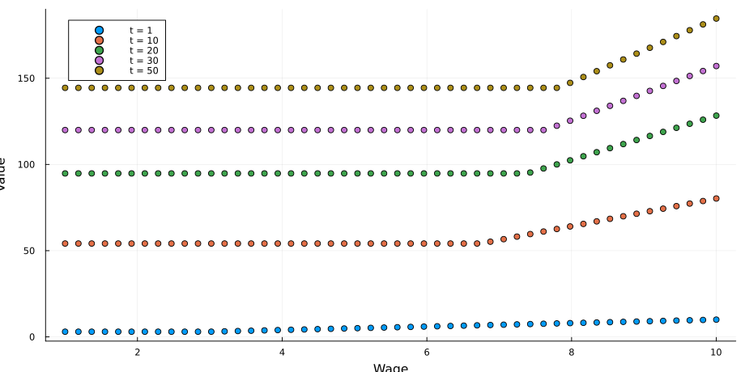

```julia
plot()
for t in [1, 10, 20, 30, 50]
    scatter!(w̄, V[t, :], label="t = $t")
end
xlabel!("Wage")
ylabel!("Value")
```

- More periods left $\rightarrow$ higher value (more opportunities to find a good wage)

# Solving with Functions

## The Bellman Iteration Function

### `iterateBellman`: Pseudocode

- Wrap the single-step Bellman update in a reusable function

```julia
function iterateBellman(V, Q, β, p, w̄, c)     # V, Q from next period
    # Compute value of accepting each wage offer
    # Compute value of rejecting (same for all wages)
    # Pick the better option for each wage
    # Compute expected value of a random offer
    # Return updated V, Q, and acceptance decision C
end
```

### `iterateBellman`: Accept vs. Reject

- First, compute the value of each option:

```julia
function iterateBellman(V, Q, β, p, w̄, c)
    V_accept = w̄ .+ β .* V                       # w̄[s] + β*V[s] for each wage s
    V_reject = c  + β  * Q                        # c + β*Q (same for all wages)
    # ...
end
```

- `V_accept` is a **vector** — one value for each wage offer
- `V_reject` is a **scalar** — same for all wages (the outside option)
- The dot in `w̄ + β * V` broadcasts element-wise: each wage $\bar{w}_s$ plus the discounted continuation $\beta V_s$

### `iterateBellman`: Full Function

```julia
function iterateBellman(V, Q, β, p, w̄, c)     # V, Q from next period
    V_accept = w̄ .+ β .* V                       # w̄[s] + β*V[s] for each wage s
    V_reject = c  + β  * Q                        # c + β*Q (same for all wages)
    V_new = max.(V_accept, V_reject)            # pick the better option
    Q_new = dot(p, V_new)                       # expected value of random offer
    C = V_accept .>= V_reject                   # 1 = accept, 0 = reject
    return (V=V_new, Q=Q_new, C=C)               # named tuple of results
end
```

```
iterateBellman (generic function with 1 method)
```

### Named Tuple Returns

- Our functions return **named tuples** instead of plain tuples:

```julia
return (V=V_new, Q=Q_new, C=C)
```

- Two ways to access the results:

```julia
ret = iterateBellman(V, Q, β, p, w̄, c)
ret.V                      # access by name — self-documenting
ret.C                      # no need to remember the order
```

```julia
V, Q, C = iterateBellman(V, Q, β, p, w̄, c) # destructuring still works!
```

**Why Named Tuples?**

With 3–4 return values, it’s easy to forget the order. Named tuples let you access results **by name** — no more guessing which output is which.

### `solveMcCall`: Pseudocode

```julia
function solveMcCall(β, p, w̄, c, T)           # T = number of periods
    # Allocate storage for V, Q, and C
    # Set base case: V with 1 period left
    # Loop from t=2 to T, calling iterateBellman each step
    # Return named tuple with V, Q, C
end
```

### `solveMcCall`: Base Case

- Start from the **last period** ($t = 1$):

```julia
function solveMcCall(β, p, w̄, c, T)
    S = length(w̄)
    V = zeros(T, S);  Q = zeros(T);  C = zeros(Int, T, S)

    V[1, :] = max.(w̄, c)                      # just pick the higher payoff
    Q[1] = dot(p, V[1, :])                     # expected value of random offer
    C[1, :] = w̄ .>= c                         # accept if wage ≥ benefits
    # ...
end
```

- `V[1, :]` stores the value function with 1 period left — simply $\max(\bar{w}_s, c)$
- `Q[1]` is the expected value of a random offer: $Q_1 = p \cdot V_1$

### `solveMcCall`: Full Function

```julia
function solveMcCall(β, p, w̄, c, T)           # T = number of periods
    S = length(w̄)                              # number of wage offers
    V = zeros(T, S);  Q = zeros(T);  C = zeros(Int, T, S)  # allocate storage

    V[1, :] = max.(w̄, c)                      # base case: V with 1 period left
    Q[1] = dot(p, V[1, :])                     # expected value with 1 period left
    C[1, :] = w̄ .>= c                         # accept if wage ≥ benefits

    for t in 2:T                                # iterate from 2 to T periods
        V[t, :], Q[t], C[t, :] = iterateBellman(V[t-1, :], Q[t-1], β, p, w̄, c)
    end                                         # uses previous period's solution
    return (V=V, Q=Q, C=C)                       # return as named tuple
end
```

```
solveMcCall (generic function with 1 method)
```

### Value Functions for 100 Periods

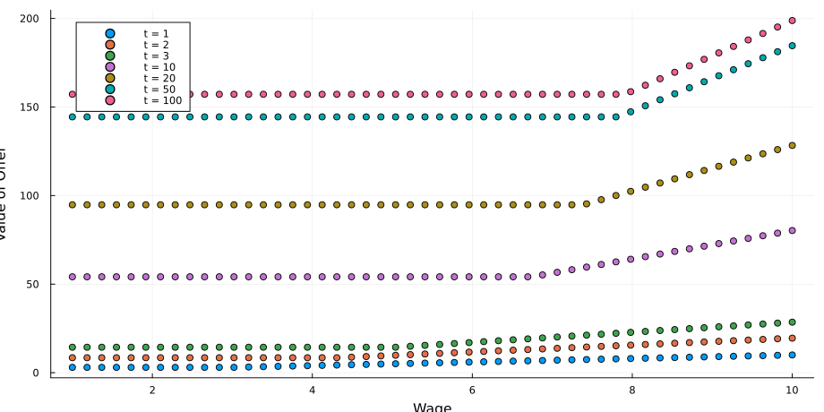

```julia
V, Q, C = solveMcCall(β, p, w̄, c, 100)       # solve for T = 100 periods
plot()                                          # initialize empty plot
for t in [1, 2, 3, 10, 20, 50, 100]            # plot selected periods
    scatter!(w̄, V[t, :], label="t = $t")       # add value function for period t
end
xlabel!("Wage")                                 # label axes
ylabel!("Value of Offer")
```

- Note: little difference between $V_{50}$ and $V_{100}$ — the value function is **converging**

# Infinite Horizon

## From Finite to Infinite

### Taking the Limit

- As $t \to \infty$, the value function converges: $V_{t,s} \approx V_{t+1,s}$
- The problem faced today is the **same** as the problem faced tomorrow
- Taking the limit of the Bellman equation:

$$V_s = \max\left\{ \bar w_s + \beta V_s,\; c + \beta Q \right\}$$

where $Q = p \cdot V$

### The Fixed Point Problem

**Fixed Point**

The infinite horizon value function satisfies a **fixed point equation**: $V$ appears on both sides.

- We solve by iterating: guess $V$, apply the Bellman equation, repeat until $V$ stops changing

### Value Function Iteration

```julia
V = max.(w̄, c)                                    # initial guess for V
C = w̄ .>= c                                      # initial guess for policy
Q = dot(p, V)                                      # initial guess for Q

dist = 1.0                                         # initialize distance
while dist > 1e-10                                 # loop until convergence
    V_new, Q_new, C = iterateBellman(V, Q, β, p, w̄, c)  # one Bellman step
    dist = norm(V - V_new, Inf)                     # max |V_new - V| across wages
    V = V_new                                       # replace old V with new
    Q = Q_new                                       # replace old Q with new
end
```

### Convergence Speed

**Why Does VFI Converge?**

The Bellman operator is a **contraction mapping** with modulus $\beta$.

- After $n$ iterations, the error is at most $\beta^n \|V_0 - V^*\|$
- With $\beta = 0.95$, each iteration shrinks the error by 5%
- Convergence is **geometric** — fast enough for most applications

### The Infinite Horizon Solution

```julia
scatter(w̄, V, label="Value", legend=:topleft)
xlabel!("Wage")
ylabel!("Value")
```

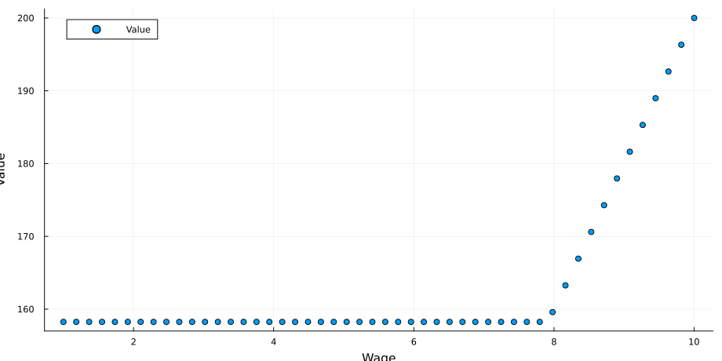

### The Optimal Policy

```julia
scatter(w̄, C, label="Accept (1) / Reject (0)", legend=:topleft)
xlabel!("Wage")
ylabel!("Choice")
```

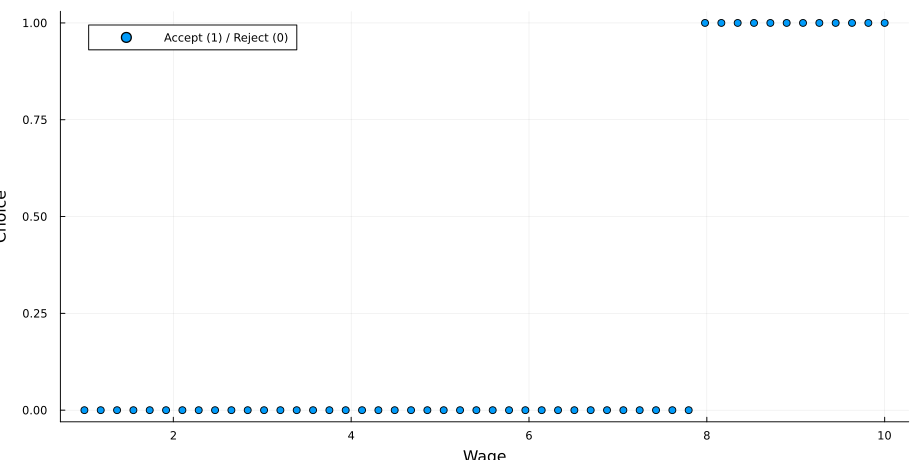

### The Reservation Wage

**Reservation Wage**

The optimal policy is a **threshold rule**: accept any wage above a cutoff (the reservation wage) and reject wages below it.

### Computing the Reservation Wage

```julia
w_res = w̄[findfirst(C .== 1)]    # first wage where worker accepts
println("Reservation wage: ", round(w_res, digits=2))
```

```
Reservation wage: 7.98
```

- The worker rejects any offer below this threshold and waits for a better one

### `solveMcCall` (Infinite Horizon): Pseudocode

```julia
function solveMcCall(β, p, w̄, c)               # no T argument → infinite horizon
    # Initialize V, Q, C with simple guesses
    # Loop: apply iterateBellman until V stops changing
    # Return named tuple with V, Q, C
end
```

### `solveMcCall` (Infinite Horizon): The Convergence Loop

- The key difference from the finite-horizon solver: we iterate **until convergence** instead of a fixed number of steps

```julia
    dist = 1.0                                  # initialize distance
    while dist > 1e-10                          # loop until convergence
        V_new, Q_new, C = iterateBellman(...)   # one Bellman step
        dist = norm(V - V_new, Inf)             # max |V_new - V| across wages
        V = V_new;  Q = Q_new                   # replace old with new
    end
```

- `norm(V - V_new, Inf)` computes the **sup-norm**: the largest absolute change across all wages
- When this is smaller than $10^{-10}$, the value function has converged

### `solveMcCall` (Infinite Horizon): Full Function

```julia
function solveMcCall(β, p, w̄, c)               # no T argument → infinite horizon
    V = max.(w̄, c);  C = w̄ .>= c;  Q = dot(p, V)  # initial guesses

    dist = 1.0                                  # initialize distance
    while dist > 1e-10                          # iterate until convergence
        V_new, Q_new, C = iterateBellman(V, Q, β, p, w̄, c)  # Bellman step
        dist = norm(V - V_new, Inf)             # check max absolute difference
        V = V_new;  Q = Q_new                   # update V and Q
    end
    return (V=V, Q=Q, C=C)                      # return as named tuple
end
```

```
solveMcCall (generic function with 2 methods)
```

# Organizing with Structs

## Why Structs?

### The Problem with Many Arguments

- Our solver: `solveMcCall(β, p, w̄, c)` — 4 separate arguments
- With firing: `solveMcCallFiring(β, p, w̄, c, α)` — 5 arguments
- As models grow, we pass more and more parameters to every function
- Easy to mix up argument order, hard to read, tedious to change
- **Solution**: bundle all model parameters into a **single object**

### Structs as Blueprints

- A **struct** defines a new data type that groups related data together
- Think of it as a **blueprint** or **template**:
  - The struct defines *what fields* a model needs (β, w̄, p, c, …)
  - An **instance** fills in *specific values* for those fields

**Analogy**

`McCallModel` is like a blank form: “every McCall model needs a β, w̄, p, and c.” Creating an instance fills in the blanks with specific numbers.

## Defining a Struct

### The `@kwdef` Macro

- Julia’s built-in `@kwdef` macro provides two useful features:
  - Define structs with **default values**
  - Combined with destructuring `(; ...)`, extract fields into local variables

### Defining `McCallModel`

```julia
@kwdef struct McCallModel
    β::Float64 = 0.95                                   # discount factor
    S::Int = 50                                          # number of wage offers
    w̄::Vector{Float64} = collect(LinRange(1., 10., S))  # wage grid
    p::Vector{Float64} = ones(S)/S                       # probabilities
    c::Float64 = 3.0                                     # unemployment benefit
    α::Float64 = 0.0                                     # firing probability
end
```

```
McCallModel
```

- `@kwdef` lets every field have a **default value**

### Creating Instances

- Use **all defaults**:

```julia
m = McCallModel()
```

```
McCallModel(0.95, 50, [1.0, 1.183673469387755, 1.3673469387755102, 1.5510204081632653, 1.7346938775510203, 1.9183673469387754, 2.1020408163265305, 2.2857142857142856, 2.4693877551020407, 2.6530612244897958  …  8.346938775510203, 8.53061224489796, 8.714285714285714, 8.89795918367347, 9.08163265306122…
```

- **Change one parameter** — only specify what’s different:

```julia
m_generous = McCallModel(c = 5.0)
```

```
McCallModel(0.95, 50, [1.0, 1.183673469387755, 1.3673469387755102, 1.5510204081632653, 1.7346938775510203, 1.9183673469387754, 2.1020408163265305, 2.2857142857142856, 2.4693877551020407, 2.6530612244897958  …  8.346938775510203, 8.53061224489796, 8.714285714285714, 8.89795918367347, 9.08163265306122…
```

### Creating Instances

- **Change multiple parameters**:

```julia
m_patient = McCallModel(β = 0.99, c = 4.0)
```

```
McCallModel(0.99, 50, [1.0, 1.183673469387755, 1.3673469387755102, 1.5510204081632653, 1.7346938775510203, 1.9183673469387754, 2.1020408163265305, 2.2857142857142856, 2.4693877551020407, 2.6530612244897958  …  8.346938775510203, 8.53061224489796, 8.714285714285714, 8.89795918367347, 9.08163265306122…
```

### Accessing Fields

- Use **dot notation** to access any field:

```julia
m.β
```

```
0.95
```

```julia
m.c
```

```
3.0
```

```julia
m.w̄[1:5]
```

```
5-element Vector{Float64}:
 1.0
 1.183673469387755
 1.3673469387755102
 1.5510204081632653
 1.7346938775510203
```

### Destructuring Fields

- Inside a function, destructuring extracts fields into local variables:

```julia
(; β, p, w̄, c) = m
β
```

```
0.95
```

**Why Destructuring?**

Instead of writing `m.β`, `m.p`, `m.w̄`, `m.c` everywhere in our math, destructuring gives us clean local variable names — the code looks the same as before.

## Rewriting with Structs

### `iterateBellman` with a Struct

```julia
function iterateBellman(m::McCallModel, V, Q)   # V, Q from next period + model
    (; β, p, w̄, c) = m                     # extract parameters
    V_accept = w̄ + β * V                       # w̄[s] + β*V[s] for each wage s
    V_reject = c + β * Q                        # c + β*Q (same for all wages)
    V_new = max.(V_accept, V_reject)            # pick the better option
    Q_new = dot(p, V_new)                       # expected value of random offer
    C = V_accept .>= V_reject                   # 1 = accept, 0 = reject
    return (V=V_new, Q=Q_new, C=C)             # named tuple of results
end
```

```
iterateBellman (generic function with 2 methods)
```

- Now only 3 arguments instead of 6 — the model carries the rest

### `solveMcCall` with a Struct

```julia
function solveMcCall(m::McCallModel)            # takes a single McCallModel
    (; β, p, w̄, c) = m                     # extract parameters
    V = max.(w̄, c);  C = w̄ .>= c;  Q = dot(p, V)

    dist = 1.0
    while dist > 1e-10
        V_new, Q_new, C = iterateBellman(m, V, Q)  # pass the model
        dist = norm(V - V_new, Inf)
        V = V_new;  Q = Q_new
    end
    return (V=V, Q=Q, C=C)                      # named tuple
end
```

```
solveMcCall (generic function with 3 methods)
```

### Using the Struct Version

```julia
m = McCallModel()
sol = solveMcCall(m)       # returns a named tuple
```

```
(V = [158.24988988232073, 158.24988988232073, 158.24988988232073, 158.24988988232073, 158.24988988232073, 158.24988988232073, 158.24988988232073, 158.24988988232073, 158.24988988232073, 158.24988988232073  …  166.93877550863462, 170.61224489635495, 174.28571428407582, 177.9591836717961, 181.63265305…
```

```julia
sol.V[1:5]                 # access value function by name
```

```
5-element Vector{Float64}:
 158.24988988232073
 158.24988988232073
 158.24988988232073
 158.24988988232073
 158.24988988232073
```

```julia
scatter(m.w̄, sol.V, label="Value", legend=:topleft)
xlabel!("Wage")
ylabel!("Value")
```

### Using the Struct Version

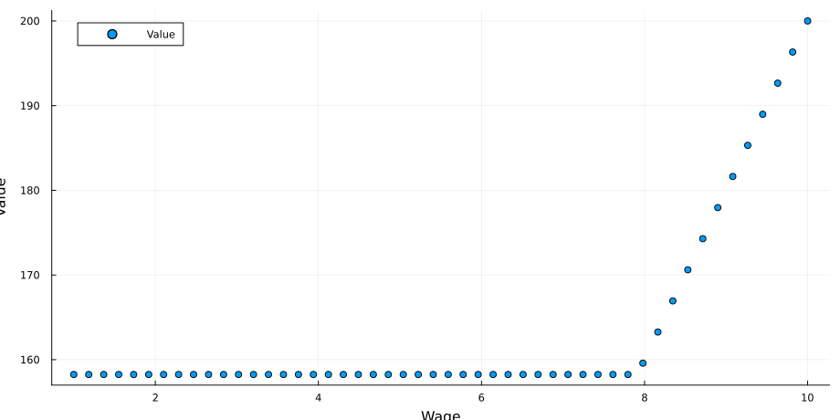

### Multiple Dispatch

**Julia’s Multiple Dispatch**

Julia picks which `solveMcCall` to call based on the argument type:

- `solveMcCall(m)` where `m::McCallModel` → struct version
- `solveMcCall(β, p, w̄, c)` → original version

Both work! Julia dispatches to the right method automatically.

## Hazard Rates

### What is the Hazard Rate?

- The **hazard rate** is the probability of leaving unemployment each period:

$$h = p_1 C_1 + p_2 C_2 + \cdots + p_S C_S = p \cdot C$$

- $C_s = 1$ if the worker accepts wage $\bar w_s$, 0 otherwise

### Computing the Hazard Rate

```julia
m = McCallModel()
sol = solveMcCall(m)
dot(m.p, sol.C)            # hazard rate using named tuple access
```

```
0.23999999999999996
```

### Expected Unemployment Duration

- If the hazard rate is $h$, the **expected duration** of unemployment is:

$$\mathbb{E}[\text{duration}] = \frac{1}{h}$$

```julia
h = dot(m.p, sol.C)
println("Hazard rate: ", round(h, digits=3))
println("Expected duration: ", round(1/h, digits=1), " periods")
```

```
Hazard rate: 0.24
Expected duration: 4.2 periods
```

### Hazard Rate and Unemployment Benefits

- How does the hazard rate change with $c$?

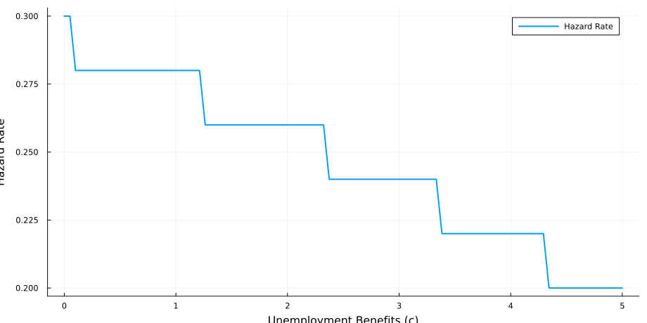

```julia
cvalues = LinRange(0, 5, 100)                       # grid of c values to try
hvalues = zeros(length(cvalues))                    # store hazard rate for each c
for i in 1:length(cvalues)                          # loop over each c
    sol = solveMcCall(McCallModel(c=cvalues[i]))    # create model, solve
    hvalues[i] = dot(p, sol.C)                      # compute hazard rate p⋅C
end
plot(cvalues, hvalues, linewidth=2, label="Hazard Rate", legend=:topright)
xlabel!("Unemployment Benefits (c)")                # label axes
ylabel!("Hazard Rate")
```

- Higher $c$ $\rightarrow$ worker is more selective $\rightarrow$ lower hazard rate

# Firing

## Model with Firing

### Adding Firing Risk

- Now suppose an employed worker gets **fired** with probability $\alpha$ at end of period
- When fired, immediately draws a new wage offer
- Let $U_t$ = value of being **unemployed** with $t$ periods left:

$$U_t = c + \beta Q_{t-1}$$

### Value of Accepting with Firing Risk

- Value of **accepting** offer $\bar w_s$:

$$\bar w_s + \beta\left[(1-\alpha) V_{t-1,s} + \alpha U_{t-1}\right]$$

### The Bellman Equation with Firing

$$\boxed{V_{t,s} = \max\left\{ \bar w_s + \beta\left[(1-\alpha) V_{t-1,s} + \alpha U_{t-1}\right],\; U_t \right\}}$$

**Effect of Firing**

Firing risk **reduces** the value of accepting a job, since employment is no longer permanent.

### Bellman Iteration with Firing

```julia
function iterateBellmanFiring(m::McCallModel, V, Q, U)  # model first
    (; β, p, w̄, c, α) = m                  # extract all parameters
    V_accept = w̄ + β * ((1-α)*V .+ α*U)        # keep job w.p. 1-α, fired w.p. α
    U_new = c + β * Q                            # unemployment: benefits + random offer
    V_new = max.(V_accept, U_new)                # pick the better option
    Q_new = dot(p, V_new)                        # expected value of random offer
    C = V_accept .>= U_new                       # 1 = accept, 0 = reject
    return (V=V_new, Q=Q_new, U=U_new, C=C)     # named tuple with U
end
```

```
iterateBellmanFiring (generic function with 1 method)
```

- 4 arguments instead of 8 — same pattern as `iterateBellman`

### Infinite Horizon with Firing

```julia
function solveMcCallFiring(m::McCallModel)      # takes a McCallModel with α > 0
    (; β, p, w̄, c, α) = m                  # extract all parameters

    V = max.(w̄, c);  C = w̄ .>= c              # initial guess for V, C
    Q = dot(p, V);    U = c                     # initial guess for Q, U

    dist = 1.0                                  # initialize distance
    while dist > 1e-10                          # iterate until convergence
        V_new, Q_new, U_new, C = iterateBellmanFiring(m, V, Q, U)  # model first
        dist = norm(V - V_new, Inf)             # max absolute change in V
        V = V_new;  Q = Q_new;  U = U_new       # update all values
    end
    return (V=V, Q=Q, U=U, C=C)                 # return as named tuple
end
```

```
solveMcCallFiring (generic function with 1 method)
```

## Comparative Statics

### Effect of Firing Probability ($\alpha$)

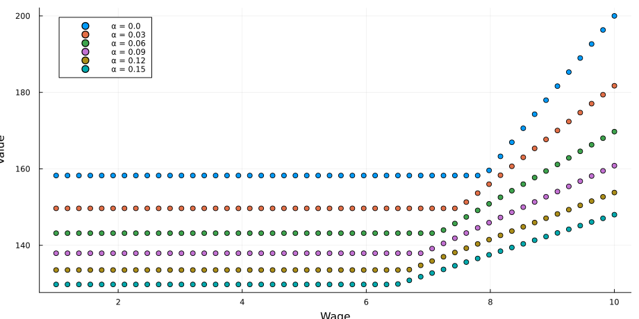

```julia
plot()                                          # initialize empty plot
for α in LinRange(0., 0.15, 6)                 # loop over 6 values of α
    sol = solveMcCallFiring(McCallModel(α=α))           # create model, solve
    scatter!(w̄, sol.V, label="α = $(round(α, digits=2))")  # add to plot
end
xlabel!("Wage")                                 # label axes
ylabel!("Value")
```

- Higher firing risk $\rightarrow$ lower value of employment $\rightarrow$ lower value overall

### Effect of Unemployment Benefits ($c$)

```julia
α = 0.02   # fix α for remaining comparative statics
```

```
0.02
```

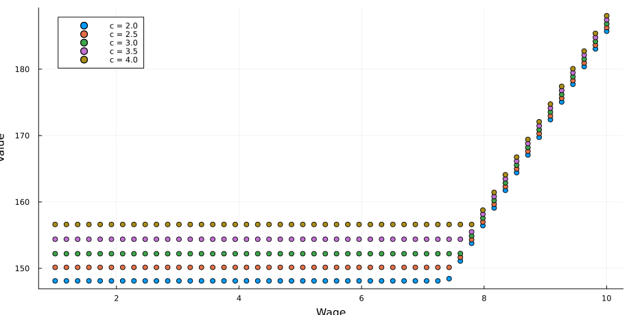

```julia
plot()                                          # initialize empty plot
for c in LinRange(2., 4., 5)                   # loop over 5 values of c
    sol = solveMcCallFiring(McCallModel(α=α, c=c))         # vary c, fix α
    scatter!(w̄, sol.V, label="c = $(round(c, digits=1))")  # add to plot
end
xlabel!("Wage")                                 # label axes
ylabel!("Value")
```

## Mean Preserving Spread

### What is a Mean Preserving Spread?

- A change in the wage distribution that **keeps the mean the same** but **increases the variance**

```julia
phat = 0.04 * ((w̄ .- 5.5) / 4.5).^2
phat .-= dot(phat, w̄) / sum(w̄)
p2 = p + phat
```

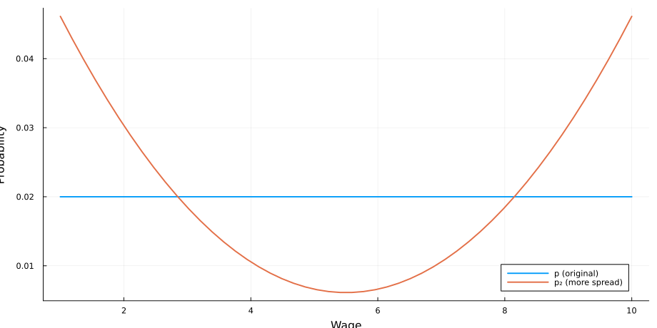

```julia
plot(w̄, p, label="p (original)", linewidth=2)
plot!(w̄, p2, label="p₂ (more spread)", linewidth=2)
xlabel!("Wage")
ylabel!("Probability")
```

### Verifying Equal Means

```julia
println("Mean under p:  ", dot(p, w̄))
println("Mean under p₂: ", dot(p2, w̄))
```

```
Mean under p:  5.500000000000001
Mean under p₂: 5.5
```

- Same mean, but $p_2$ places more weight on both **high** and **low** wages

### Effect on Value and Policy

```julia
sol  = solveMcCallFiring(McCallModel(α=α))          # original wages
sol2 = solveMcCallFiring(McCallModel(α=α, p=p2))   # more spread
scatter(w̄, sol.V, label="p = original")
scatter!(w̄, sol2.V, label="p = more spread")
xlabel!("Wage")
ylabel!("Value")
```

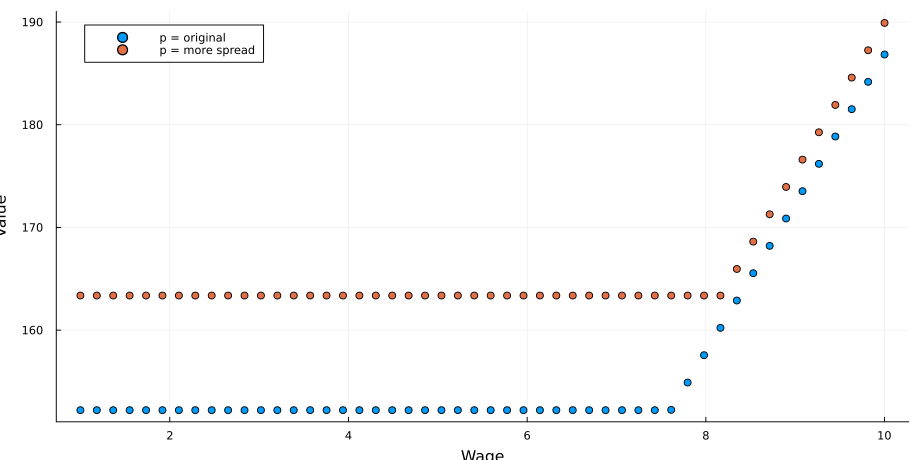

### Effect on Acceptance Policy

```julia
scatter(w̄, sol.C, label="p = original")
scatter!(w̄, sol2.C, label="p = more spread")
xlabel!("Wage")
ylabel!("Choice (1 = accept)")
```

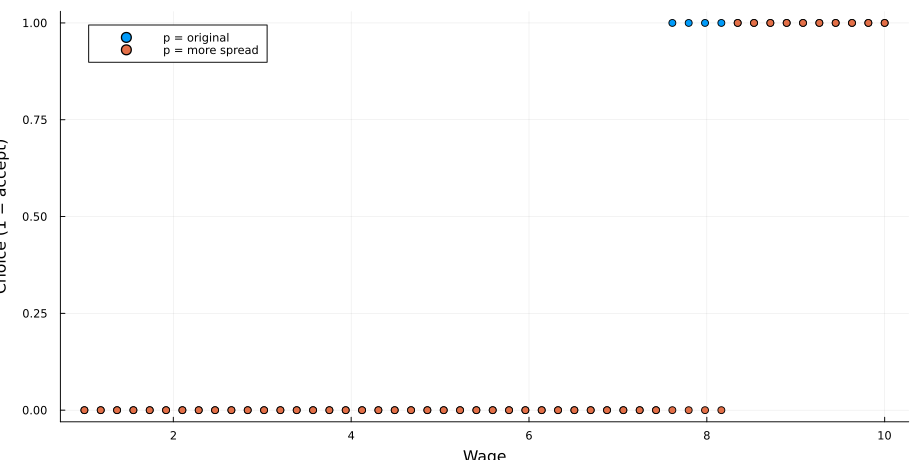

### Why Does More Variance Help?

**Option Value**

The worker is **strictly better off** with more variance. The option to reject bad offers means the worker benefits from upside risk without fully bearing downside risk.

# Summary

### Key Takeaways

**Concepts**

- Bellman equation and backward induction
- Reservation wage policy
- Value function iteration for infinite horizon
- Hazard rates and unemployment duration
- Comparative statics: $c$, $\alpha$, wage distribution

**Julia Tools**

- `max.()` for element-wise max
- `dot()` for expected values
- `norm()` for convergence checks
- Structs with `@kwdef`, destructuring `(; ...)`
- Named tuples for self-documenting returns
- Multiple dispatch

**Remember**

The McCall model shows that **search is valuable**: a rational worker will reject low offers and wait for better ones, especially when the future is long ($T$ large) and they are patient ($\beta$ high).